# FSelectorRcpp

entropy-based feature selection algorithms with sparse matrix support

Krzysztof Slomczynski

September 28, 2017

# What is FSelectorRcpp package?

# Rcpp implementation of FSelector package

Advantages:

- free of Java/Weka
- additional sparse matrix support
- equipped with parallel backend (doParallel – R, OpenMP – C++)
- unified output from called functions

# Installation

# CRAN or GitHub

Available on CRAN, one can simply run

```r
install.packages("FSelectorRcpp")
```

or get the developer version with

```r
devtools::install_github("mi2-warsaw/FSelectorRcpp")

# windows users should have Rtools for devtools installation
# https://cran.r-project.org/bin/windows/Rtools/
```

# Motivation

# Feature selecting purpose

Feature selection algortihms are necessary for handling two problems related with too big data sets:

- training time
- model interpretation

# Feature selection methods

- Principal Component Analysis or Singular Value Decomposition
  - hard to interpret in the final model
- Boruta, genetic algorithms or simulated annealing techniques
  - computations can take days
- Decision Trees, LASSO or Regularized Support Vector Machines
  - still quite time consuming and sometimes used without understanding

# Entropy Based Feature Selection

Every feature can be checked independently so that computations can be performed in parallel.

Hence entropy based feature selection is

- fast
- easy to understand

# Entropy

# The measure of uncertainty

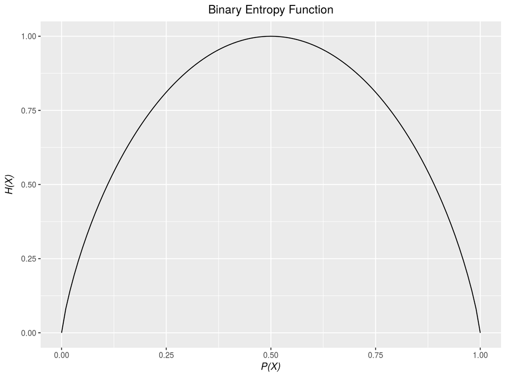

# Entropy equation

$$H_{\alpha}(X) = -\sum_{x}P(x)log_{\alpha}(P(x))$$
$$H_{\alpha}(X, Y) = -\sum_{x, y}P(x, y)log_{\alpha}(P(x, y))$$

Units for different $\alpha$ parameter:

$$bit: \alpha = 2$$
$$nat: \alpha = e$$
$$ban, dit, hartley: \alpha = 10$$

# Three methods

$$infogain: H(Class) + H(Attribute) - H(Class, Attribute)$$
$$gainratio: \frac{H(Class) + H(Attribute) - H(Class, Attribute)}{H(Attribute)}$$
$$symuncert: 2 \frac{H(Class) + H(Attribute) - H(Class, Attribute)}{H(Attribute) + H(Class)}$$

First one is simply mutual information

$$I(X; Y) = H(X) + H(Y) - H(X, Y)$$

# Quick Workflow

# Information gain

- easy, linear algorithm
- computes the entropy of a dependent and explanatory variables
- computes conditional entropy of dependent variable with respect to each explanatory variable separately

# Information gain – code

```r
info_gain <-
  information_gain(             # Calculate the score for each attribute
    formula = Species ~ .,      # that is on the right side of the formula.
    data = iris,                # Attributes must exist in the passed data.
    type  = "infogain",         # Choose the type of a score to be calculated.
    threads = 2                 # Set number of threads in a parallel backend.
  )

info_gain
    attributes importance
1 Sepal.Length  0.4521286
2  Sepal.Width  0.2672750
3 Petal.Length  0.9402853
4  Petal.Width  0.9554360
```

# Information gain – code

```r
cutted_attrs <-
  cut_attrs(                    # Then take attributes with the highest rank.
    attrs = info_gain,
    k = 2                       # For example: 2 attrs with the higehst rank.
  )

cutted_attrs
[1] "Petal.Width"  "Petal.Length"

new_formula <-
  to_formula(                   # Create a new formula object with
    attrs = cutted_attrs,       # the most influencial attrs.
    class = "Species"
  )

new_formula
Species ~ Petal.Width + Petal.Length
<environment: 0x29e3080>
```

# Information gain – code

```r
model <-
  glm(
    formula = new_formula,      # Use that formula in any classification algorithm.
    data = iris,
    family = "binomial"
  )

model

Call:  glm(formula = new_formula, family = "binomial", data = iris)

Coefficients:
 (Intercept)   Petal.Width  Petal.Length
      -69.45         33.89         17.60

Degrees of Freedom: 149 Total (i.e. Null);  147 Residual
Null Deviance:      191
Residual Deviance: 5.17e-09     AIC: 6
```

# Information gain – piping

```r
information_gain(
    formula = Species ~ .,
    data = iris,
    type  = "infogain",
    threads = 2
  ) %>%
  cut_attrs(
    k = 2
  ) %>%
  to_formula(
    attrs = .,
    class = "Species"
  ) %>%
  glm(
    formula = .,
    data = iris,
    family = "binomial"
  )
```

# Feature search

- checks combinations of subsets of the specified attributes’ set
- score the currently considered subset, depending on the criterion passed to `fun` parameter.

# Feature search - code

```r
eval_adjR2_lm <-      # Create a scorer function.
  function(
    attributes,       # That takes the currently considered subset of attributes
    data,             # from a specified dataset.
    dependent =
      names(data)[1]  # To find features that best describe the dependent variable.
  ) {
    summary(          # In this situation we take the adj.r.squared statistic
      lm(             # from the summary of a linear model object.
        to_formula(   # This is the score to use to choose between considered
          attributes, # subsets of attributes.
          dependent
        ),
        data = data)
    )$adj.r.squared
  }
```

# Feature search - code

```r
set.seed(42)
random <- sample(x = letters, size = 150, replace = TRUE)
ran_iris <- cbind(iris, random)
head(ran_iris)
  Sepal.Length Sepal.Width Petal.Length Petal.Width Species random
1          5.1         3.5          1.4         0.2  setosa      x
2          4.9         3.0          1.4         0.2  setosa      y
3          4.7         3.2          1.3         0.2  setosa      h
4          4.6         3.1          1.5         0.2  setosa      v
5          5.0         3.6          1.4         0.2  setosa      q
6          5.4         3.9          1.7         0.4  setosa      n

fs <- feature_search(    # works in 2 modes – 'exhaustive' and 'greedy'
  attributes =
    names(ran_iris)[-1], # takes attribues and creates combinations of it's subsets
  fun = eval_adjR2_lm,   # calculates the score of a subset that depends on the
  data = ran_iris,       # evaluator function passed in the 'fun' parameter
  mode = "exhaustive",   # 'exhaustive' means to check all possible
  sizes =                # attributes' subset combinations
    3:5                  # of sizes passed in 'sizes'.
)
```

# Feature search - code

```r
fs$best
   Sepal.Width Petal.Length Petal.Width Species random   values
11           1            1           1       1      0 0.862705

fs$all
   Sepal.Width Petal.Length Petal.Width Species random    values
1            1            1           1       0      0 0.8557065
2            1            1           0       1      0  0.859538
3            1            1           0       0      1 0.8376647
4            1            0           1       1      0  0.725002
5            1            0           1       0      1 0.7061277
6            1            0           0       1      1 0.7144209
7            0            1           1       1      0 0.8322213
8            0            1           1       0      1 0.7662291
9            0            1           0       1      1 0.8326902
10           0            0           1       1      1 0.6701464
11           1            1           1       1      0  0.862705
12           1            1           1       0      1 0.8529765
13           1            1           0       1      1 0.8619427
14           1            0           1       1      1 0.7223287
15           0            1           1       1      1 0.8319703
16           1            1           1       1      1 0.8624321
```

# Feature search - code

```r
fs$fun
function(
    attributes,       # That takes the currently considered subset of attributes
    data,             # from a specified dataset.
    dependent =
      names(data)[1]  # To find features that best describe the dependent variable.
  ) {
    summary(          # In this situation we take the adj.r.squared statistic
      lm(             # from the summary of a linear model object.
        to_formula(   # This is the score to use to choose between considered
          attributes, # subsets of attributes.
          dependent
        ),
        data = data)
    )$adj.r.squared
  }
<bytecode: 0x39d3a10>

fs$call
feature_search(attributes = names(ran_iris)[-1], fun = eval_adjR2_lm,
    data = ran_iris, mode = "exhaustive", sizes = 3:5)
```